# Searching

Searching adalah proses mencari data tertentu di dalam sebuah kumpulan data (list/array). Tujuan nya Mengetahui apakah data ada atau tidak dan mengetahui posisi/index data.

## 1. LINEAR SEARCH

Pengertian

Linear Search atau Sequential Search adalah metode pencarian data dengan cara memeriksa elemen satu per satu secara berurutan sampai data ditemukan atau seluruh data selesai dicek.

Cara Kerja Mulai dari index pertama Bandingkan data dengan nilai yang dicari Jika sama → data ditemukan Jika belum sama → lanjut ke data berikutnya Berhenti saat data ditemukan atau list habis

Contoh Data List = [1,7,11,23,39,43,56] First index = 0 Last index = 6 Len = 7

```python
# Linear Search

data = [1, 7, 11, 23, 39, 43, 56]
cari = 23

found = False

for i in range(len(data)):
    if data[i] == cari:
        found = True
        posisi = i

if found:
    print("Data ditemukan")
    print("Posisi index:", posisi)
else:
    print("Data tidak ditemukan")
```

```
Data ditemukan
Posisi index: 3
```

## Sequential Search

Sequential Search merupakan teknik pencarian data dengan cara membandingkan data yang dicari dengan seluruh data yang terdapat pada kumpulan data secara satu persatu, mulai dari data pertama sampai dengan data terakhir. Ilustrasi sequential search ini dapat dilihat pada Gambar 1 berikut.

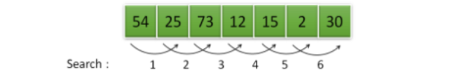

Terdapat dua konsep untuk sequential search berdasarkan kumpulan data yang akan dicari, yaitu Unordered List Sequential Search dan Ordered List Sequential Search

### Unordered List Sequential Search

Pada unordered list sequential search, data berada pada keadaan acak, tidak terurut, sehingga pencarian harus dilakukan mulai dari indeks awal sampai indeks terakhir dari data, atau pencarian berhenti ketika data sudah ditemukan

### Ordered List Sequential Search

Pada ordered list sequential search, data sudah dalam keadaan terurut, hal ini tentunya dapat mengurangi waktu komputasi pencarian.

```python
# Sequential Search Unordered
def sequential_search_unordered(data, target):
    for i in range(len(data)):
        if data[i] == target:
            return i
    return -1


# Sequential Search Ordered
def sequential_search_ordered(data, target):
    for i in range(len(data)):
        if data[i] == target:
            return i

        # Berhenti jika data sekarang lebih besar dari target
        elif data[i] > target:
            return -1

    return -1


# Contoh penggunaan
data_unordered = [12, 5, 8, 20, 1]
data_ordered = [1, 5, 8, 12, 20]

target = 8

# Unordered
hasil1 = sequential_search_unordered(data_unordered, target)

if hasil1 != -1:
    print("Unordered: Data ditemukan di index", hasil1)
else:
    print("Unordered: Data tidak ditemukan")


# Ordered
hasil2 = sequential_search_ordered(data_ordered, target)

if hasil2 != -1:
    print("Ordered: Data ditemukan di index", hasil2)
else:
    print("Ordered: Data tidak ditemukan")
```

```
Unordered: Data ditemukan di index 2
Ordered: Data ditemukan di index 2
```

### 2. Binary Search

Binary Search adalah metode pencarian yang mencari data dengan membagi list menjadi dua bagian terus menerus. Data harus dalam keadaan terurut (sorted).

Cara Kerja Binary Search:

1. Tentukan data tengah (middle)
2. Bandingkan dengan data yang dicari
3. Jika lebih kecil → cari di kiri
4. Jika lebih besar → cari di kanan
5. Ulangi sampai data ditemukan

```python
def binarySearch(alist, item):

    first = 0
    last = len(alist) - 1
    found = False

    while first <= last and not found:

        midpoint = (first + last) // 2

        if alist[midpoint] == item:
            found = True

        else:
            if item < alist[midpoint]:
                last = midpoint - 1
            else:
                first = midpoint + 1

    return found


testlist = [0, 1, 2, 8, 13, 17, 19, 32, 42]

print(binarySearch(testlist, 3))
```

```
False
```